# TidyVerse - AHCA Polls

Mikhail Groysman

November 21, 2018

# AHCA Polls

## Data source

https://github.com/fivethirtyeight/data/blob/master/ahca-polls/ahca_polls.csv

Collection of AHCA polls extracted from different websites.

## Load Libraries

```r
#install.packages("ggplot2")
#install.packages("tidyverse")
#install.packages("factoextra")
#install.packages("reshape")
library(reshape)
library(stringr)
library(XML)
library(RCurl)
library(RJSONIO)
library(tidyr)
library(dplyr)
library(ggplot2)
library(knitr)
options(knitr.table.format = "html")
library(tidyverse)  # data manipulation
library(cluster)    # clustering algorithms
library(factoextra)
options(stringsAsFactors = FALSE)
```

## Introduction.

The data in GitHub contains summary of AHSA repeal polls.We want to do simple cleaning and analysis of the data.

## Read CSV file.

- Add “others” collumn (people who did not either oppose or favor the repeal. I assume these individuals had no opinion).
- Fix typoes.
- Fix dates.
- Calculate days per poll.
- There was a mistake in one of the record. Pollster name was recorded incorrectly.
- Calculate length of poll question.
- Run summary function for dataframe.

```r
polls<-read.csv(file='https://raw.githubusercontent.com/fivethirtyeight/data/master/ahca-polls/ahca_polls.csv', header=TRUE, sep=",")

polls$Others<-100-(polls$Favor+polls$Oppose)

polls$Pollster[polls$Pollster == "Qunnipiac"] <- "Quinnipiac"

polls$Pollster[polls$Pollster == 'YouGov' & polls$End=='5/13/17'] <- 'Economist/YouGov'

polls$StartD<-as.Date(polls$Start,"%m/%d/%y")

polls$EndD<-as.Date(polls$End,"%m/%d/%y")

polls$days <-as.numeric(polls$EndD-polls$StartD+1)

polls$newpoll = str_wrap(polls$Pollster, width = 10)

polls$textlen<-str_length(polls$Text)

summary(polls)
```

```
##     Start               End              Pollster             Favor
##  Length:15          Length:15          Length:15          Min.   :17.00
##  Class :character   Class :character   Class :character   1st Qu.:23.50
##  Mode  :character   Mode  :character   Mode  :character   Median :31.00
##                                                           Mean   :28.33
##                                                           3rd Qu.:31.50
##                                                           Max.   :38.00
##      Oppose          Url                Text               Others
##  Min.   :44.00   Length:15          Length:15          Min.   :13.0
##  1st Qu.:46.50   Class :character   Class :character   1st Qu.:19.5
##  Median :48.00   Mode  :character   Mode  :character   Median :22.0
##  Mean   :50.67                                         Mean   :21.0
##  3rd Qu.:55.00                                         3rd Qu.:23.0
##  Max.   :62.00                                         Max.   :29.0
##      StartD                EndD                 days
##  Min.   :2017-05-04   Min.   :2017-05-06   Min.   :1.000
##  1st Qu.:2017-05-08   1st Qu.:2017-05-14   1st Qu.:4.500
##  Median :2017-05-13   Median :2017-05-20   Median :6.000
##  Mean   :2017-05-17   Mean   :2017-05-21   Mean   :5.467
##  3rd Qu.:2017-05-25   3rd Qu.:2017-05-30   3rd Qu.:7.000
##  Max.   :2017-06-09   Max.   :2017-06-11   Max.   :8.000
##    newpoll             textlen
##  Length:15          Min.   :115.0
##  Class :character   1st Qu.:148.0
##  Mode  :character   Median :181.0
##                     Mean   :218.9
##                     3rd Qu.:265.0
##                     Max.   :540.0
```

## Basic Plots.

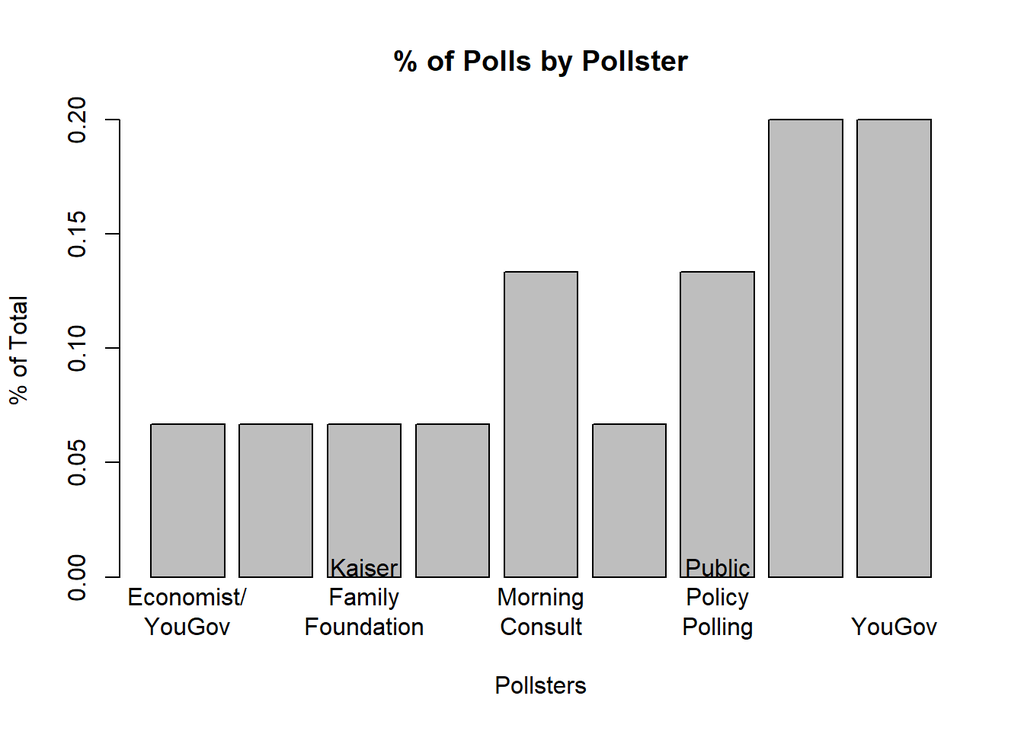

```r
pollfreq<-prop.table(table(polls$newpoll))

barplot(pollfreq, xlab="Pollsters", ylab="% of Total", main="% of Polls by Pollster")
```

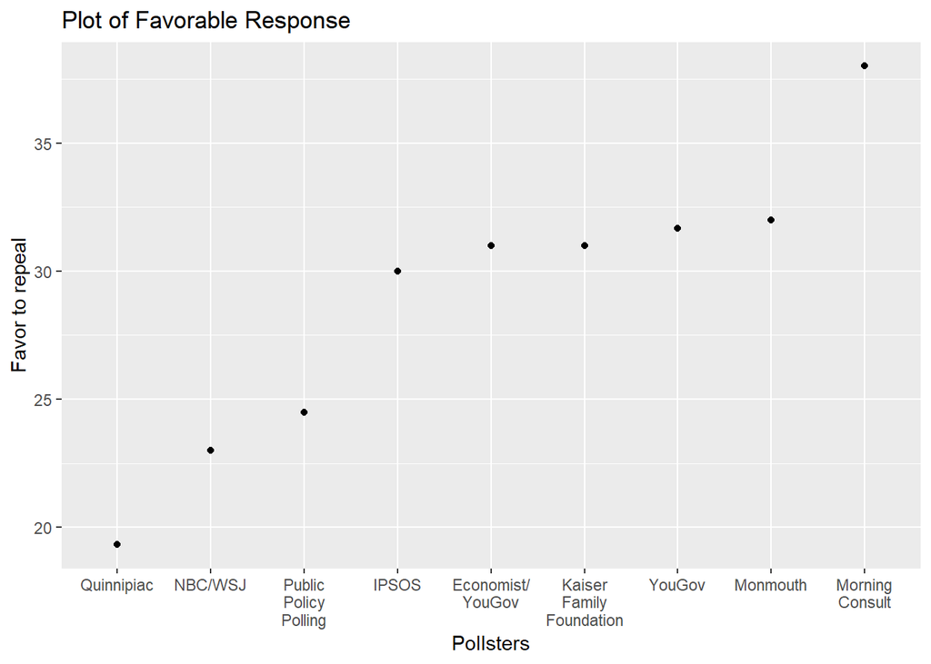

```r
AveByPollster<-polls %>% group_by(newpoll) %>% summarise(avgF = mean(Favor),avgOpp= mean(Oppose),avgOth= mean(Others), avgD=mean(days),avgL=mean(textlen))

AveByPollster$spread<-AveByPollster$avgOpp-AveByPollster$avgF

ggplot(AveByPollster, aes(x=reorder(newpoll,avgF), y=avgF)) + geom_point()+ggtitle("Plot of Favorable Response") + labs(x = "Pollsters", y="Favor to repeal")
```

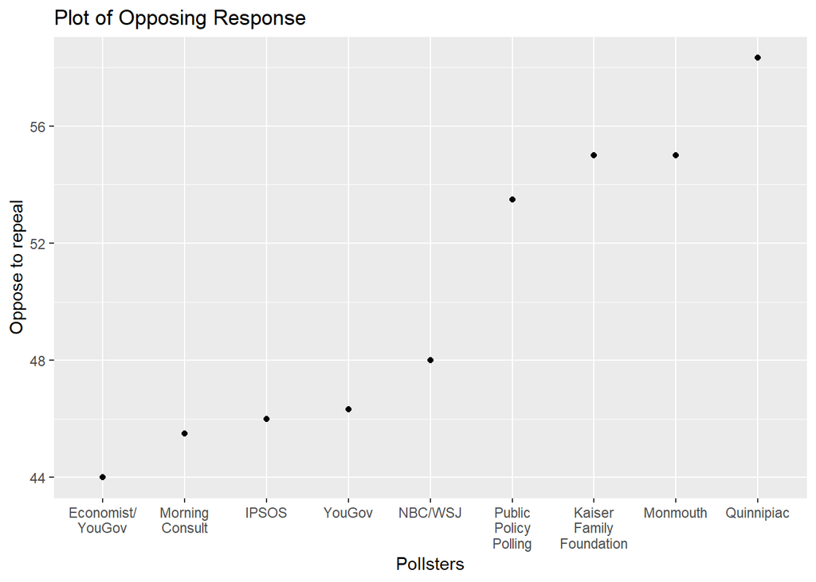

```r
ggplot(AveByPollster, aes(x=reorder(newpoll,avgOpp), y=avgOpp)) + geom_point()+ggtitle("Plot of Opposing Response") + labs(x = "Pollsters", y="Oppose to repeal")
```

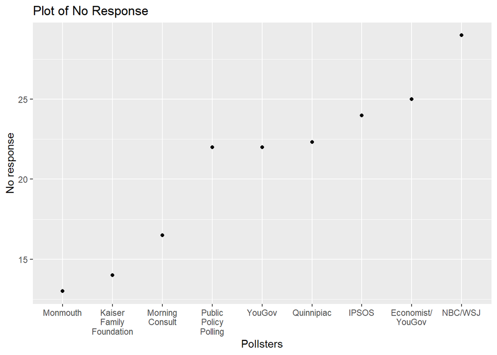

```r
ggplot(AveByPollster, aes(x=reorder(newpoll,avgOth), y=avgOth)) + geom_point()+ggtitle("Plot of No Response") + labs(x = "Pollsters", y="No response")
```

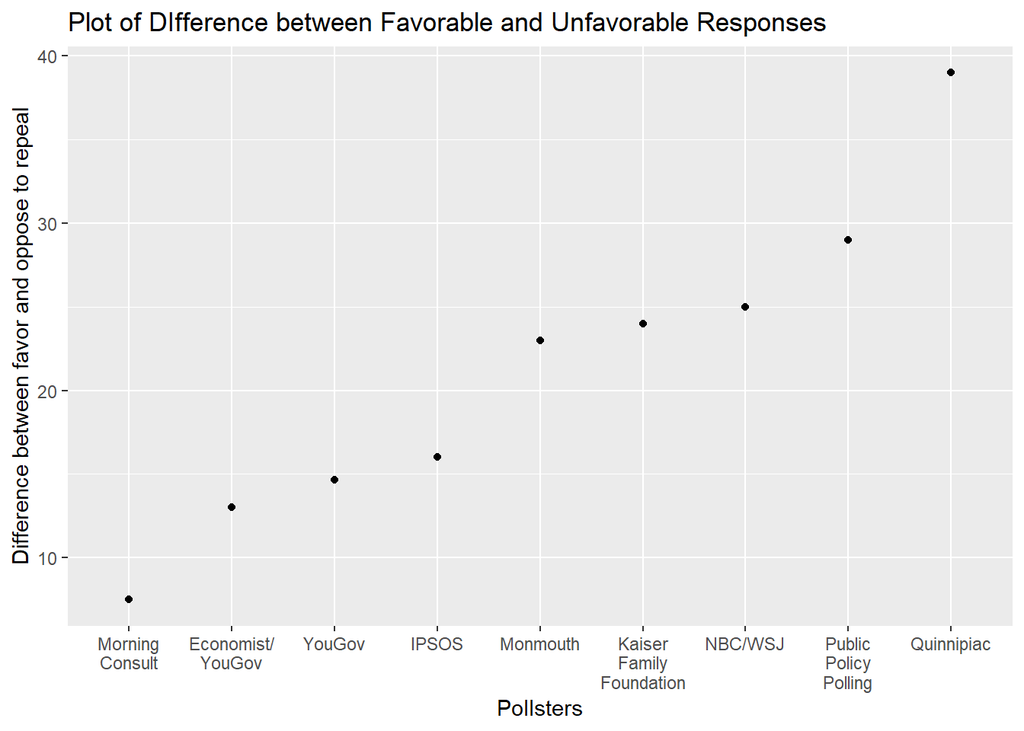

```r
ggplot(AveByPollster, aes(x=reorder(newpoll,spread), y=spread)) + geom_point()+ggtitle("Plot of DIfference between Favorable and Unfavorable Responses") + labs(x = "Pollsters", y="Difference between favor and oppose to repeal")
```

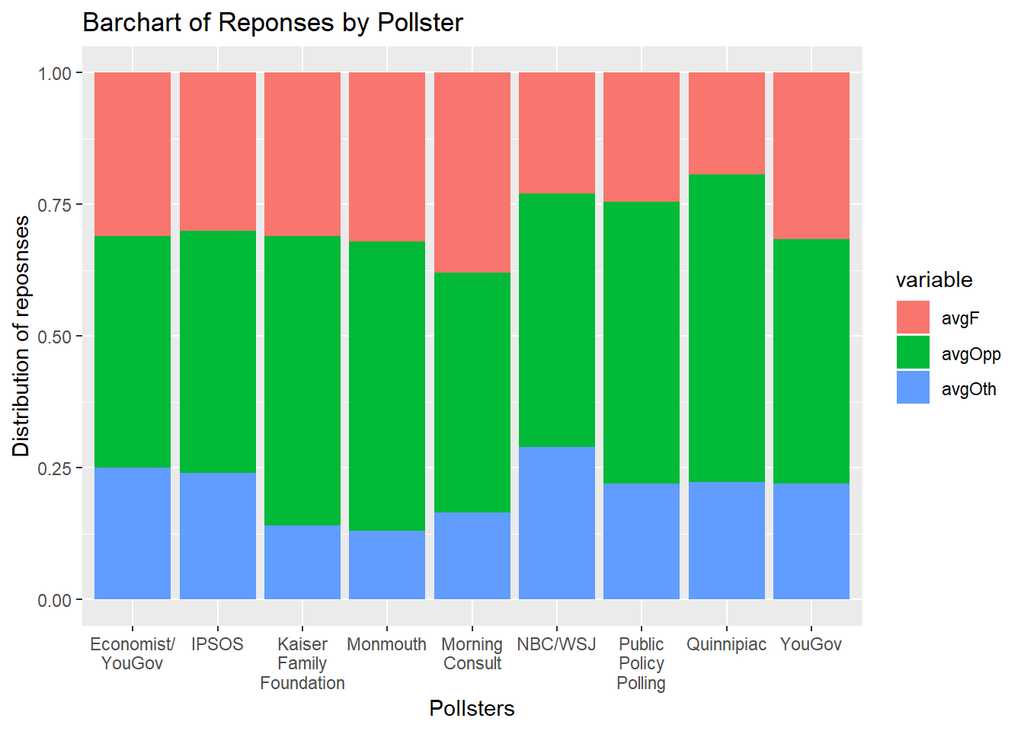

```r
AveByPollster1<-select(AveByPollster,newpoll,avgF,avgOpp,avgOth)

AveByPollster1 <- as.data.frame(AveByPollster1)

AveByPollster2<-melt(AveByPollster1,id = c("newpoll"))

ggplot(AveByPollster2, aes(fill=variable, y=value, x=newpoll)) + geom_bar( stat="identity", position="fill")+ggtitle("Barchart of Reponses by Pollster") + labs(x = "Pollsters", y="Distribution of reposnses")
```

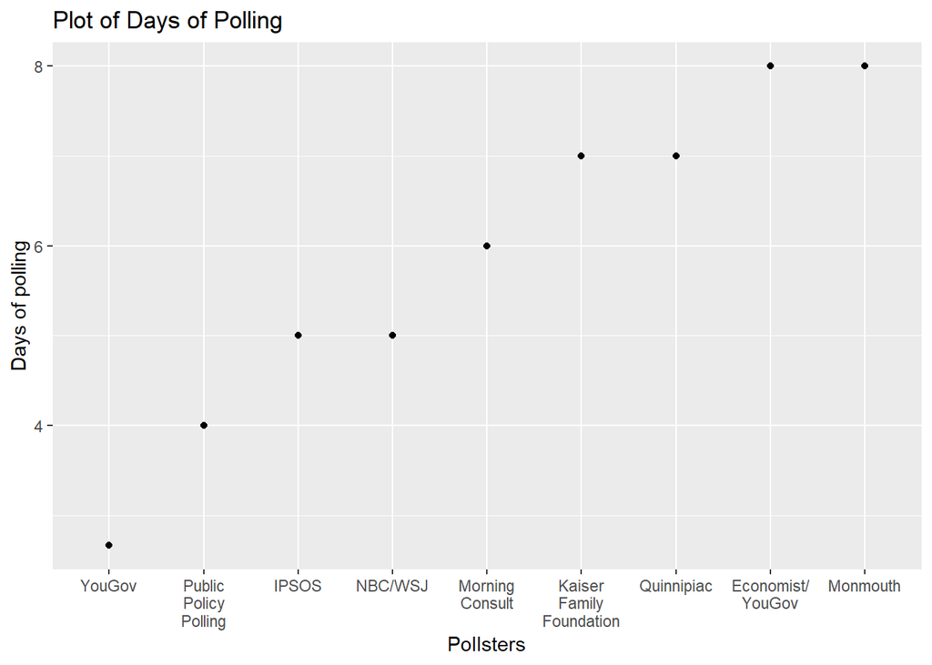

```r
ggplot(AveByPollster, aes(x=reorder(newpoll,avgD), y=avgD)) + geom_point()+ggtitle("Plot of Days of Polling") + labs(x = "Pollsters", y="Days of polling")
```

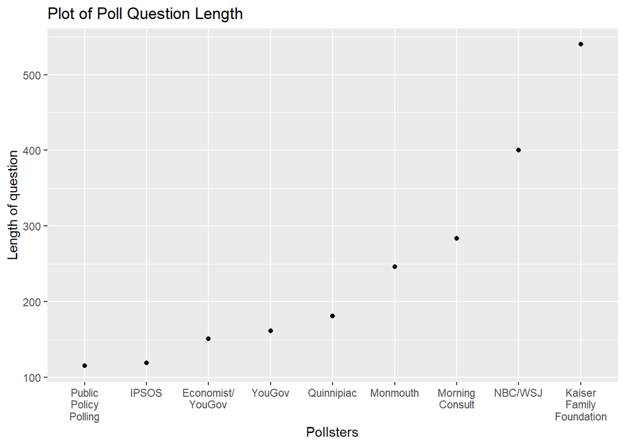

```r
ggplot(AveByPollster, aes(x=reorder(newpoll,avgL), y=avgL)) + geom_point()+ggtitle("Plot of Poll Question Length") + labs(x = "Pollsters", y="Length of question")
```

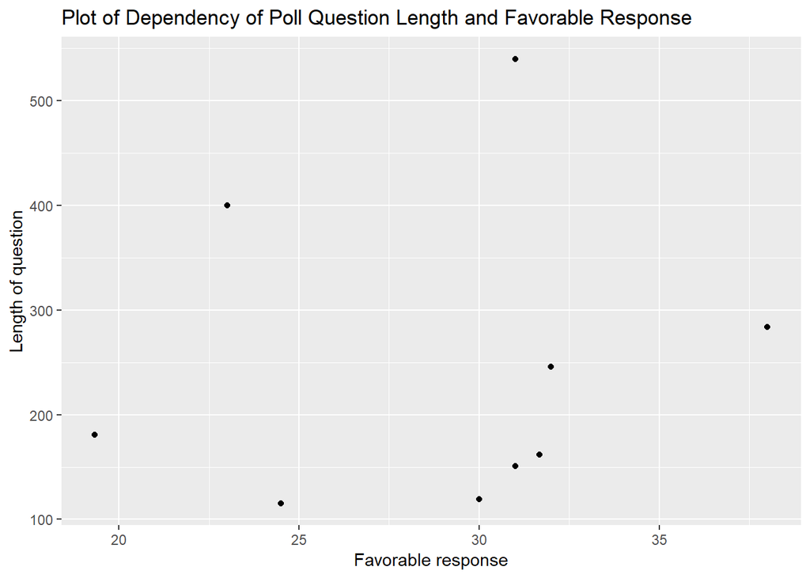

```r
ggplot(AveByPollster, aes(x=avgF, y=avgL)) + geom_point()+ggtitle("Plot of Dependency of Poll Question Length and Favorable Response")  + labs(x = "Favorable response", y="Length of question")
```

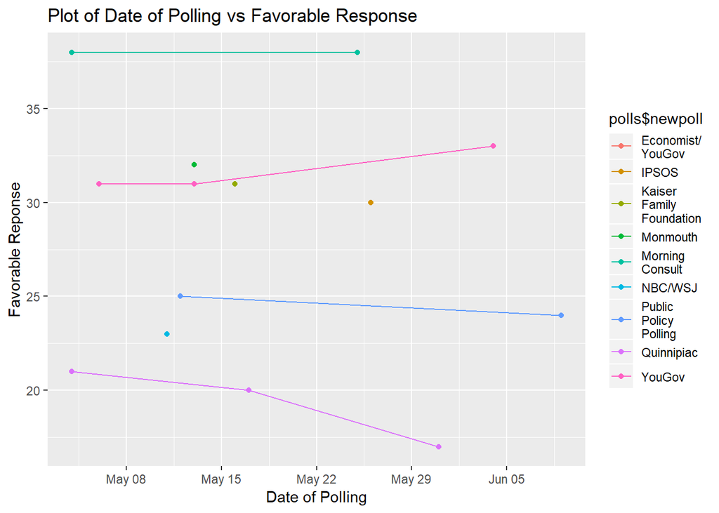

```r
qplot(polls$StartD, polls$Favor,geom=c("point", "line"),colour = polls$newpoll, main="Plot of Date of Polling vs Favorable Response", xlab="Date of Polling", ylab="Favorable Reponse")
```

```r
x <- AveByPollster[2:4]

y <- AveByPollster[6]

cor(x, y)
```

```
##              avgL
## avgF    0.1044624
## avgOpp  0.2288785
## avgOth -0.3375974
```

```r
library("ggpubr")
```

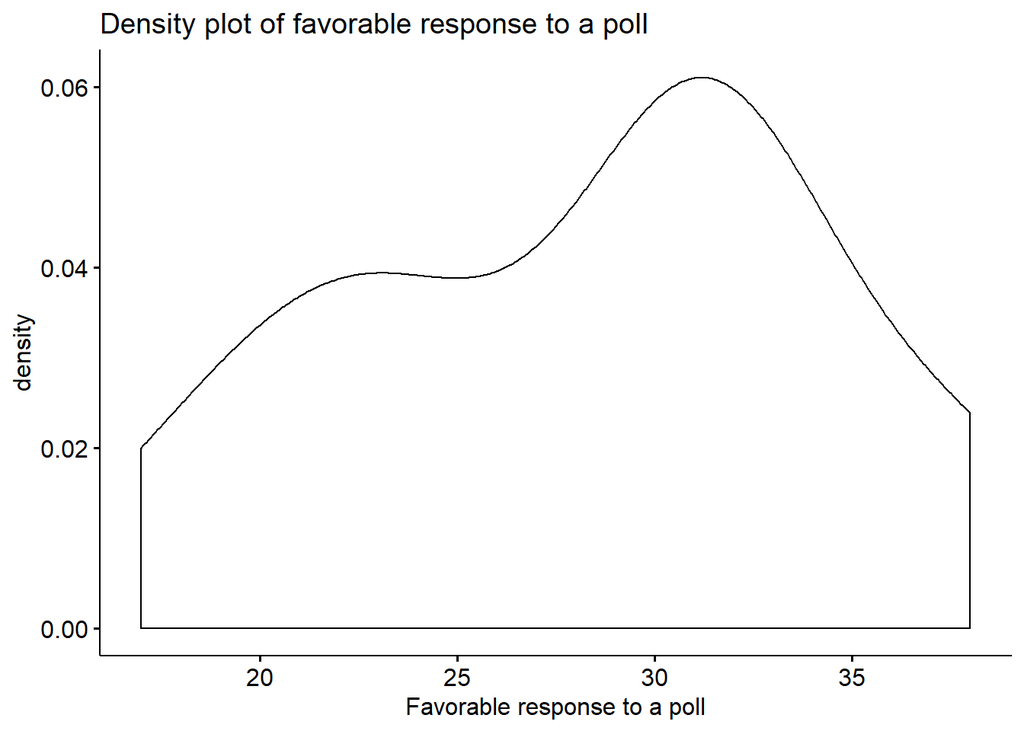

```r
ggdensity(polls$Favor,
          main = "Density plot of favorable response to a poll",
          xlab = "Favorable response to a poll")
```

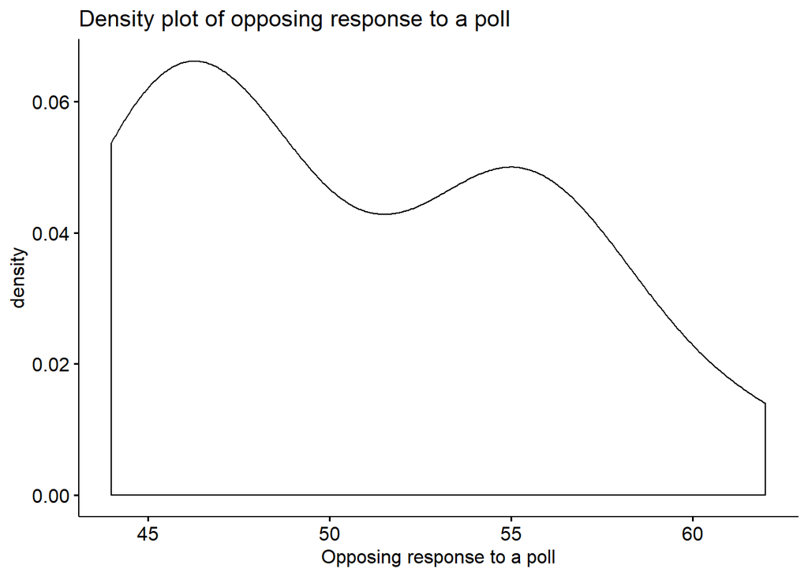

```r
library("ggpubr")
ggdensity(polls$Oppose,
          main = "Density plot of opposing response to a poll",
          xlab = "Opposing response to a poll")
```

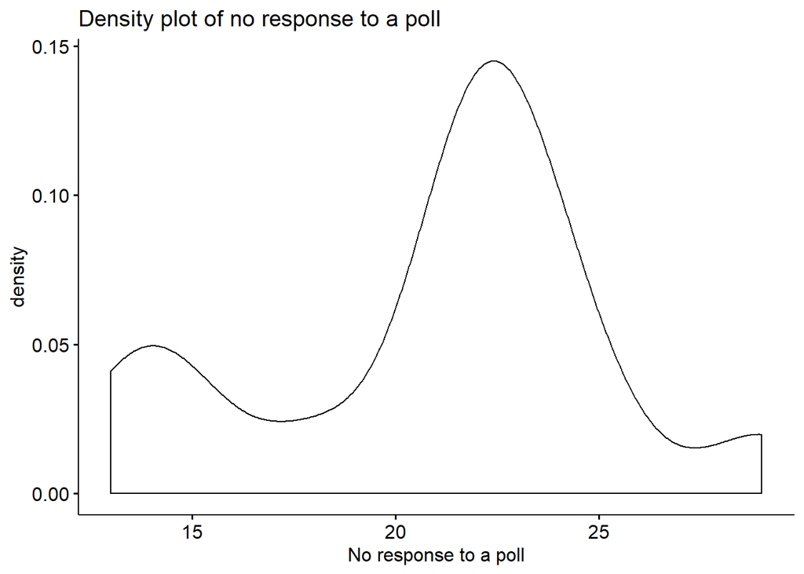

```r
library("ggpubr")
ggdensity(polls$Others,
          main = "Density plot of no response to a poll",
          xlab = "No response to a poll")
```

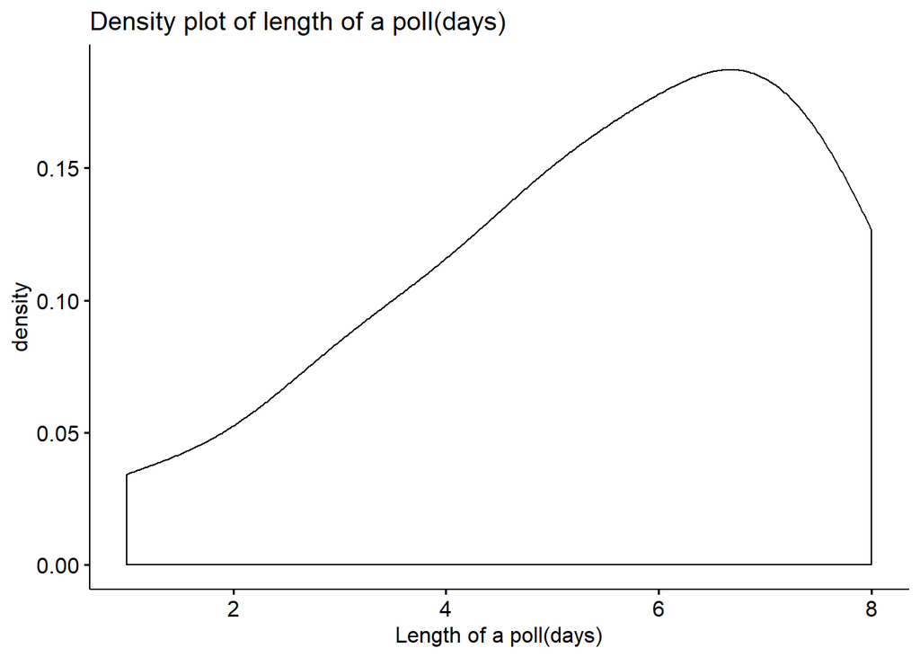

```r
library("ggpubr")
ggdensity(polls$days,
          main = "Density plot of length of a poll(days)",
          xlab = "Length of a poll(days)")
```

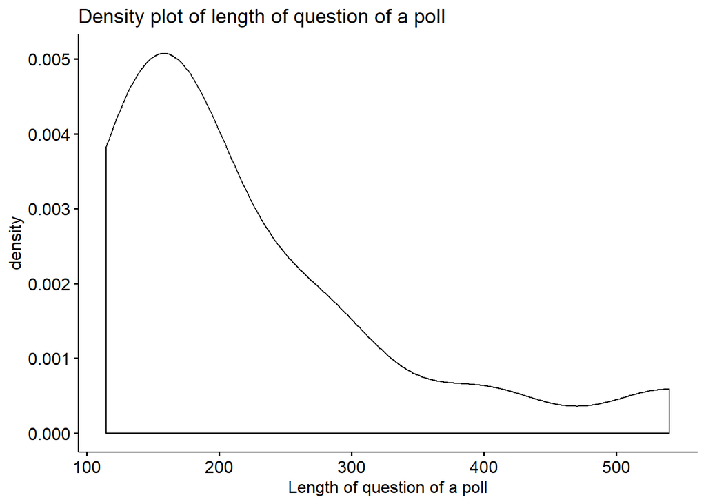

```r
library("ggpubr")
ggdensity(polls$textlen,
          main = "Density plot of length of question of a poll",
          xlab = "Length of question of a poll")
```